# Desigualdad y Acceso a Internet (1990–2019)

17 Sep 2025

## Objetivo del Proyecto

El objetivo principal de este proyecto es analizar la relación entre la desigualdad económica, medida a través del coeficiente de Gini, y el acceso a Internet, medido como el porcentaje de no usuarios normalizados por población.

### Objetivos específicos

- Integrar bases de datos internacionales de desigualdad, uso de Internet y población en un panel anual por país (1990–2019).
- Normalizar las cifras de no usuarios de Internet para hacer comparaciones robustas entre países.
- Calcular un ratio entre Gini y no uso de Internet, como indicador combinado de desigualdad y brecha digital.
- Explorar correlaciones globales, entre países y dentro de países a lo largo del tiempo.
- Visualizar la evolución espacial y temporal del fenómeno mediante mapas interactivos y gráficos.

## Tabla de Indicadores

La tabla muestra un resumen de los principales indicadores del panel utilizado, incluyendo el número de países y años cubiertos, así como los coeficientes de correlación entre desigualdad y no uso de Internet.

| Indicador | Valor |
| --- | --- |
| Países | 195 |
| Años (min–max) | 1990–2019 |
| Correlación global (Pearson) | 0.273 |
| Correlación global (Spearman) | 0.240 |
| Correlación entre países (between) | 0.442 |
| Correlación dentro de países (within) | 0.115 |

## Relación Global

El gráfico muestra la relación entre el coeficiente de Gini y el no uso de Internet normalizado, con un ajuste lineal para todos los países y años del panel.

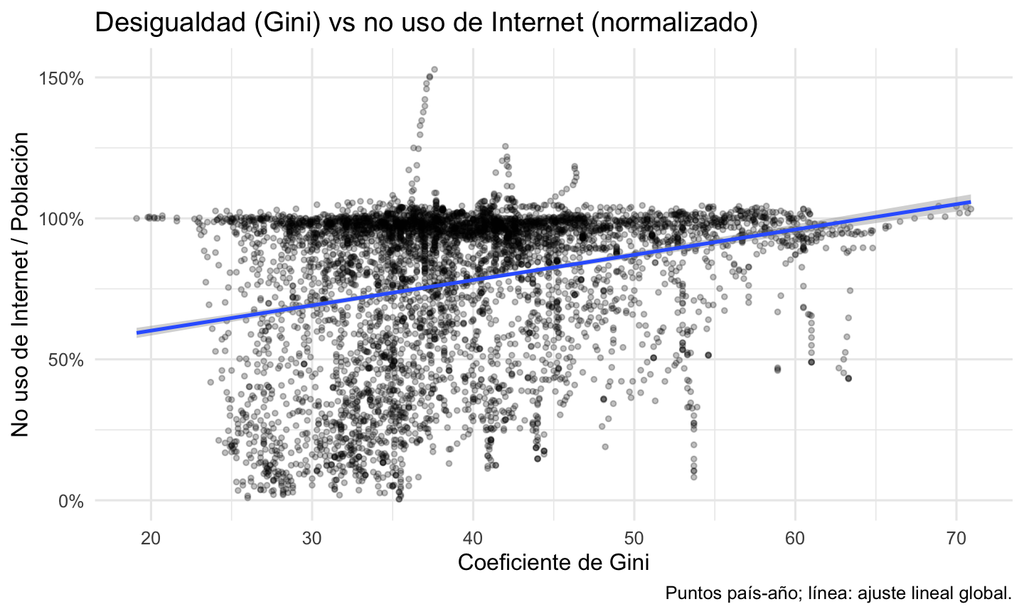